# Tarea 7

Equipo 3

2025-04-28

```r
library(dplyr)
```

```r
library(tidyr)
library(ggplot2)
library(ggpubr)

# Cargamos los datos
data <- read.csv2("EP07 Datos.csv",sep = ",",dec = ".",header = TRUE)

# Transformamos los milisegundos a segundos en las columnas de los tiempos
data$tiempo.A <- data$tiempo.A/1000
data$tiempo.B <- data$tiempo.B/1000
data$tiempo.C <- data$tiempo.C/1000

# Convertimos los porcentajes a decimales en las columnas de los rendimientos
data$mejor.A <- data$mejor.A/100
data$mejor.B <- data$mejor.B/100
data$mejor.C <- data$mejor.C/100
```

### 1.

Observando los datos, la memorista sospecha que hay diferencias significativas en el tiempo de ejecución entre las versiones A y C del algoritmo cuando las instancias tienen 60 o más nodos. **¿Los datos respaldan la intuición de la memorista?**. Para responder, filtren los datos para tener las instancias con 60 o más nodos y seleccionen las columnas de los tiempos de ejecución de las versiones A y C en formato ancho. Usando como semilla el valor 73, obtenga muestras aleatorias independientes de 24 tiempos registrados por la versión A y 20 tiempos registrados por la versión C del algoritmo. Realicen un análisis estadístico pertinente (enunciar hipótesis, revisar condiciones, seleccionar pruebas ómnibus y post-hoc según corresponda) para responder la pregunta planteada, utilizando pruebas no paramétricas de ser necesario.

```r
# Filtramos los datos para tener las mediciones donde el numero de nodos son mayores o iguales a 60 de las versiones A y C
data_60 <- data %>%
  filter(n.nodos >= 60) %>%
  select(tiempo.A, tiempo.C)

# Llevamos los datos a formato ancho
data_60_long<- data_60 %>%
  pivot_longer(cols = everything(), names_to = "version", values_to = "tiempo")

# Establecemos la semilla y obtenemos las muestras aleatorias de 24 tiempos para A y 20 para C
set.seed(73)
sample_A_60 <- sample_n(data_60, 24) %>% select(tiempo.A)
sample_C_60 <- sample_n(data_60, 20) %>% select(tiempo.C)
```

Las hipotesis a contrastar serian las siguientes:

- **Hipótesis nula (H0):** No hay diferencias significativas en el tiempo de ejecución entre las versiones A y C del algoritmo.
- **Hipótesis alternativa (H1):** Hay diferencias significativas en el tiempo de ejecución entre las versiones A y C del algoritmo.

Como nos encontramos con un contraste de medias, nuestra primera opcion es ocupar una prueba t, pero como debemos contrastar 2 muestras, revisaremos la normalidad de los datos mediante un grafico q-q, para dar una respuesta definitiva.

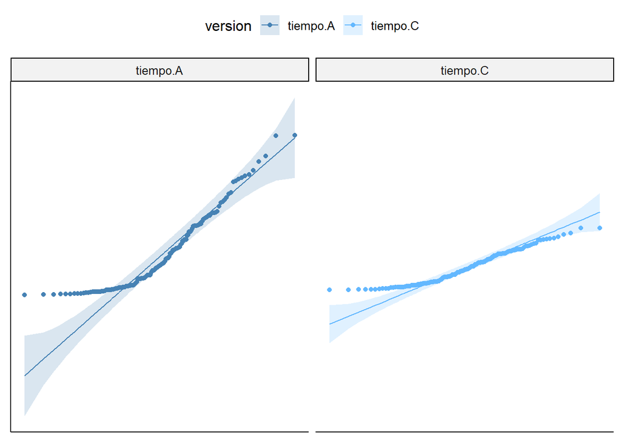

```r
tonos_azules = c ("steelblue","steelblue1")
g <- ggqqplot (data_60_long, x = "tiempo", y = "version",color = "version" , palette = tonos_azules)
g <- g + facet_wrap(~ version )
g <- g + rremove ("x.ticks") + rremove ("x.text")
g <- g + rremove ("y.ticks") + rremove ("y.text")
g <- g + rremove ("axis.title")
print ( g )
```

Como los datos no sigue razonablemente una distribucion normal, descartamos la prueba t y ocuparemos una prueba no paramétrica. En este caso, la prueba de Wilcoxon, pero la version no pareada, ya que se miden las mismas distintas instancias en los algoritmos.

Para la prueba de Wilcoxon se deben cumplir las siguientes condiciones:

**1. Los pares de observaciones son independientes entre si:** Esta condicion se cumple, ya que las mediciones de tiempo para cada versión son independientes entre sí.

**2. La escala de medición empleada para ambas muestras debe ser a lo menos ordinal:** Esta condición se cumple, ya que los tiempos de ejecución son medidos en segundos, lo que permite ordenarlos.

Luego de verificadas las condiciones, procedemos a aplicar la prueba, sin ser muy exigentes, ya que las muestras son grandes (mayores a 5):

```r
# Aplicamos la prueba de Wilcoxon
wilcox.test(sample_A_60$tiempo.A,sample_C_60$tiempo.C)
```

```
##
##  Wilcoxon rank sum exact test
##
## data:  sample_A_60$tiempo.A and sample_C_60$tiempo.C
## W = 260, p-value = 0.649
## alternative hypothesis: true location shift is not equal to 0
```

### 2.

La memorista también sospecha que, al comparar las mismas instancias de iguales características, las mejores soluciones encontradas por las versiones A y B tienen rendimientos distintos. **¿Estará en lo cierto?** Para responder, filtren los datos para tener las instancias con 60 o más nodos y seleccionen las columnas con el mejor rendimiento de las versiones A y B en formato ancho. Usando como semilla el valor 13, obtengan una muestra aleatoria de 22 instancias. Realicen un análisis estadístico pertinente (enunciar hipótesis, revisar condiciones, seleccionar pruebas ómnibus y post-hoc según corresponda) para responder la pregunta planteada, utilizando pruebas no paramétricas de ser necesario.

**Desarrollo:** Primero se filtran los datos según lo indicado por el enunciado. A continuación, se realiza un gráfico de los datos entregados por las soluciones A y B para analizar la simetría de estos.

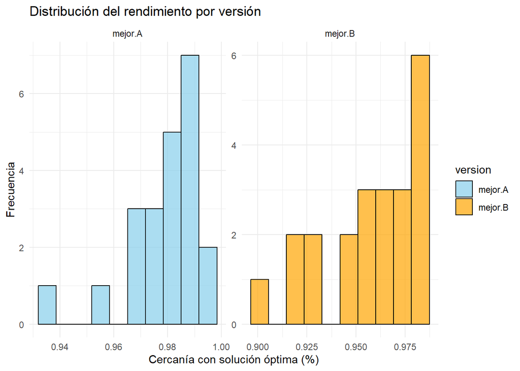

```r
datos_filtrados <- data %>%
  filter(n.nodos >= 60) %>%
  select(instancia, mejor.A, mejor.B) %>%
  sample_n(22)

datos_largos <- datos_filtrados %>%
  pivot_longer(cols = c(mejor.A, mejor.B),
               names_to = "version",
               values_to = "rendimiento")

ggplot(datos_largos, aes(x = rendimiento, fill = version)) +
  geom_histogram(color = "black", bins = 10, alpha = 0.7) +
  facet_wrap(~version, scales = "free") +
  theme_minimal() +
  labs(title = "Distribución del rendimiento por versión",
       x = "Cercanía con solución óptima (%)",
       y = "Frecuencia") +
  scale_fill_manual(values = c("mejor.A" = "skyblue", "mejor.B" = "orange"))
```

Se puede observar del gráfico que los datos no son simetricos y presentan unos cuantos valores atípicos, por lo que para resolver la pregunta se opta por una prueba no paramétrica, las cuales son más robustas en estas condiciones ya que requieren menos supuestos, más específicamente, se usará la prueba de rangos con signo de Wilcoxon.

Ya verificadas las condiciones, se procede a docimar las hipótesis y a realizar la prueba de rangos con signo de Wilcoxon:

**Hipótesis:** (Notar que debido a que se utilizará una prueba con rangos, las hipótesis se plantean en términos de medianas)

**Hipótesis nula (H₀):** La mediana de las diferencias de rendimiento entre los algoritmos A y B es igual a 0.

**Hipótesis alternativa (H₁):** La mediana de las diferencias de rendimiento entre los algoritmos A y B es distinta de 0.

```r
wilcox.test(datos_filtrados$mejor.A, datos_filtrados$mejor.B, paired = TRUE)
```

```
##
##  Wilcoxon signed rank exact test
##
## data:  datos_filtrados$mejor.A and datos_filtrados$mejor.B
## V = 236, p-value = 9.871e-05
## alternative hypothesis: true location shift is not equal to 0
```

**Resultados y conclusión:**

Dado que el valor de p es menor que 0.05, se rechaza la hipótesis nula. Esto indica que hay evidencia estadísticamente significativa para afirmar que el rendimiento de los algoritmos A y B es diferente al resolver instancias con 60 o más nodos.

### 3.

La memorista sospecha que hay diferencias significativas en el tiempo de ejecución entre las versiones del algoritmo cuando las instancias de prueba tienen 50 o más nodos. **¿Los datos respaldan la intuición de la memorista?** Para responder, filtren los datos para tener las instancias con 50 o más nodos y seleccionen las columnas con los tiempos de ejecución registrados (en formato ancho). Usando como semilla el valor 43, obtengan muestras aleatorias independientes de 15, 15 y 13 tiempos registrados por las versiones A, B y C, respectivamente. Realicen un análisis estadístico pertinente (enunciar hipótesis, revisar condiciones, seleccionar pruebas ómnibus y post-hoc según corresponda) para responder la pregunta planteada, utilizando pruebas no paramétricas de ser necesario.

En primer lugar, se filtran las instancias para seleccionar las de nuestro interés, quitando las columnas innecesarias, para luego tomar la muestra solicitada, en este caso, **muestras aleatorias independientes de 15, 15 y 13 tiempos registrados por las versiones A, B y C** y hacer el procedimiento con la semilla:

```r
# filtro instancias
muestra3 <- data %>%
  filter(n.nodos >= 50) %>%
  select(instancia, tiempo.A, tiempo.B, tiempo.C)

# seleccion muestra solicitada
nA <- 15; nB <- 15; nC <- 13
nI <- nA + nB + nC

# semilla 43
set.seed(43)
i <- sample(1:nrow(muestra3), nI)
seleccion <- muestra3[i, ]
tiempo.A <- seleccion[["tiempo.A"]][1:nA]
tiempo.B <- seleccion[["tiempo.B"]][(nA+1):(nA+nB)]
tiempo.C <- seleccion[["tiempo.C"]][(nA+nB+1):nI]

datos_largos3 <- data.frame(
  Instancia = seleccion[["instancia"]],
  Algoritmo = c(rep("A", nA), rep("B", nB), rep("C", nC)),
  Tiempo = c(tiempo.A, tiempo.B, tiempo.C)
)
datos_largos3[["Instancia"]] <- factor(datos_largos3[["Instancia"]])
datos_largos3[["Algoritmo"]] <- factor(datos_largos3[["Algoritmo"]])
```

Como cada muestra posee instancias de prueba distintas, es decir, 1-15 SOLO para A, 16-30 SOLO para B y 31-43 SOLO para C, todo ello considerando la semilla de 43 y lo explicado anteriormente de la seleccion de muestra (15, 15, 13), se considera la aplicación de ANOVA para determinar si la memorista posee o no la razón, para ello se verifican las condiciones de su aplicación:

**1. Independencia entre muestras:** esta condición se cumple dado que no hay elementos en común por lo explicado anteriormente.

**2. Variable dependiente con escala de intervalos iguales:** también se cumple, pues al tratarse del tiempo, este corresponde a una medición física.

**3. Normalidad**

**4. Homogeneidad de varianzas**

En lo que respecta a los puntos 3 y 4, deben ser comprobados mediante pruebas visuales, es decir, gráficos (en este caso gráficos q-q):

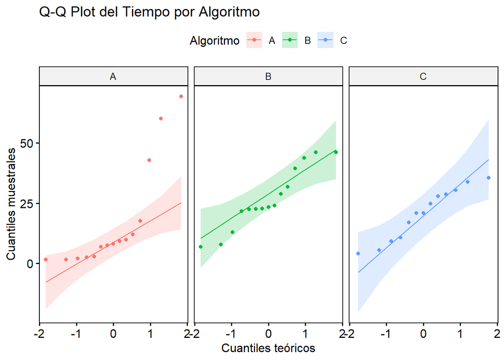

```r
datos_largos3[["Tiempo"]] <- datos_largos3[["Tiempo"]] / 60

p3 <- ggqqplot(
  datos_largos3,
  x = "Tiempo",
  color = "Algoritmo",
  facet.by = "Algoritmo",
  title = "Q-Q Plot del Tiempo por Algoritmo",
  xlab = "Cuantiles teóricos",
  ylab = "Cuantiles muestrales"
)
p3 <- p3 + facet_grid(~ Algoritmo)
print(p3)
```

- **H0:** Los tiempos promedios que tardan los algoritmos en resolver las instancias con 50+ nodos son similares.
- **HA:** Al menos uno de los algoritmos posee tiempos promedios significativamente distintos a uno de los otros algoritmos (con 50+ nodos).

Ahora, se verifican las condiciones para dicha prueba:

**1. Los pares de observaciones son independientes entre si:** condición confirmada anteriormente.

**2. La variable independiente debe tener a lo menos 2 niveles:** esta condición también se cumple dado que posee más de 2 niveles, en este caso serían los algoritmos A, B y C.

**3. La escala de la variable dependiente debe ser, a lo menos, ordinal:** condición confirmada anteriormente también mediante la explicación de las mediciones físicas.

Verificadas las condiciones, se aplica la prueba:

```r
# se define un nivel de significación estandar o comun (0.05!!)
alfa <- 0.05
prueba3 <- kruskal.test(Tiempo ~ Algoritmo, data = datos_largos3)
print(prueba3)
```

```
##
##  Kruskal-Wallis rank sum test
##
## data:  Tiempo by Algoritmo
## Kruskal-Wallis chi-squared = 6.9506, df = 2, p-value = 0.03095
```

Bajo lo anterior, la prueba indica que hay suficiente evidencia para rechazar H0 en favor de HA, pues se obtuvo un p_value = 0.03095 (p_value < 0.05). De esta forma, es posible decir que al menos uno de los algoritmos posee tiempos promedios significativamente distintos a uno de los otros algoritmos (con 50+ nodos).

Ahora, en vista de que se encontraron diferencias (HA), es necesario hacer un procedimiento post-hoc, para ello se utiliza la prueba de Wilcoxon-Mann-Whitney entre pares de grupos, aplicando el ajuste de Benjamini & Hochberg:

```r
posthoc1 <- pairwise.wilcox.test(
  datos_largos3[["Tiempo"]],
  datos_largos3[["Algoritmo"]],
  p.adjust.method = "BH",
  paired = FALSE
)
print(posthoc1)
```

```
##
##  Pairwise comparisons using Wilcoxon rank sum exact test
##
## data:  datos_largos3[["Tiempo"]] and datos_largos3[["Algoritmo"]]
##
##   A     B
## B 0.044 -
## C 0.133 0.254
##
## P value adjustment method: BH
```

De lo anterior se detecta una diferencia significativa entre A y B, pues se obtuvo un p_value < 0.05 (p_value = 0.044), mientras que no se detectan diferencias significativas entre los algoritmos A y C ni entre B y C (p > 0.05 en ambos casos), por lo que no es posible afirmar que estos pares difieran en su rendimiento (con un 95% de confianza).

### 4.

La memorista también sospecha que, al comparar las mismas instancias con iguales características, las mejores soluciones encontradas por las diferentes versiones del algoritmo tienen rendimientos distintos. **¿Estará en lo cierto?** Para responder, filtren los datos para tener las instancias con 50 o más nodos y seleccionen las columnas con los mejores rendimientos registrados. Usando como semilla el valor 71, obtengan una muestra aleatoria de 22 instancias. Lleven los datos a formato largo y utilicen una prueba no paramétrica apropiada para analizar los datos obtenidos. Realicen un análisis estadístico pertinente (enunciar hipótesis, revisar condiciones, seleccionar pruebas ómnibus y post-hoc según corresponda) para responder la pregunta planteada, utilizando pruebas no paramétricas de ser necesario.

```r
# Filtramos los datos para tener las mediciones donde el numero de nodos son mayores o iguales a 60 de las versiones A y C
data_50 <- data %>%
  filter(n.nodos >= 50)

# LLevamos los datos a formato largo
data_50_long<- data_50 %>%
  select(mejor.A, mejor.B, mejor.C) %>%
  pivot_longer(cols = everything(), names_to = "version", values_to = "tiempo")

# Establecemos la semilla y obtenemos las muestras aleatorias de 24 tiempos para A y 20 para C
set.seed(71)
sample_50 <- sample_n(data_50_long, 22)
```

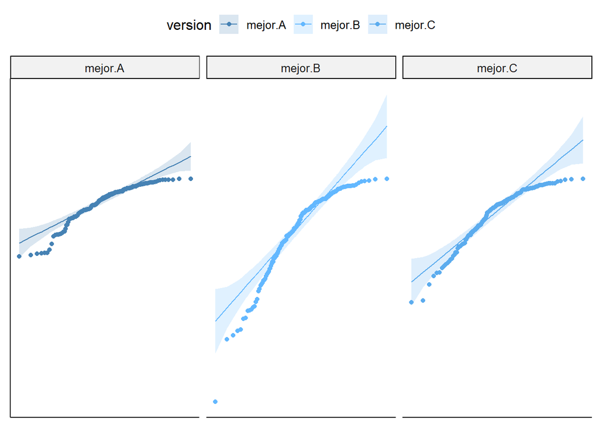

```r
tonos_azules = c ("steelblue","steelblue1","steelblue2")
g <- ggqqplot (data_50_long, x = "tiempo", y = "version",color = "version" , palette = tonos_azules)
g <- g + facet_wrap(~ version )
g <- g + rremove ("x.ticks") + rremove ("x.text")
g <- g + rremove ("y.ticks") + rremove ("y.text")
g <- g + rremove ("axis.title")
print ( g )
```

Como los datos no sigue razonablemente una distribucion normal, descartamos la prueba t y ocuparemos una prueba no paramétrica para mas de 2 muestras. En este caso, la prueba de Kruskal-Wallis, ya que se miden distintas instancias en los algoritmos.

**1. La escala de la variable dependiente debe ser, a lo menos, ordinal:** Esta condición se cumple, ya que los rendimientos son medidos en porcentajes, lo que permite ordenarlos.

**2. Las observaciones son independiente entre si:** Esta condición se cumple, ya que las mediciones de rendimiento para cada versión son independientes entre sí.

**3. La variable independiente debe ser categórica y tener a lo menos 2 niveles:** Esta condición se cumple, ya que tenemos tres versiones del algoritmo (A, B y C).

```r
# Aplicamos la prueba de Kruskal-Wallis
kruskal.test(tiempo ~ version, data = sample_50)
```

```
##
##  Kruskal-Wallis rank sum test
##
## data:  tiempo by version
## Kruskal-Wallis chi-squared = 8.3386, df = 2, p-value = 0.01546
```

```r
# Realizamos la prueba posthoc de wilcox con la correccion de Benjamini y Hochberg

posthoc <- pairwise.wilcox.test(sample_50$tiempo, sample_50$version,p.adjust.method = "BH")
print(posthoc)
```

```
##
##  Pairwise comparisons using Wilcoxon rank sum exact test
##
## data:  sample_50$tiempo and sample_50$version
##
##         mejor.A mejor.B
## mejor.B 0.017   -
## mejor.C 0.330   0.159
##
## P value adjustment method: BH
```